# Fundamentals

IQA Lecture 1

Charles Lanfear

2026-10-14

## Today

- Math Review
  - Variables, vectors, and matrices
  - Lines and curves
  - Derivatives
- Programming
  - Indexing and Subsetting
  - Logical Expressions

# Math review

[figure not shown]

## Variables

**Variables** are symbols representing sets of one or more **elements** which might take any number of values.

- Letters like $x$, $y$, and $z$ are commonly used to indicate variables.
  - e.g., $x = 3$
- Capital letters ($X$) or letters with an index ($x_i$) refer to variables with multiple values—that is, with *dimensions*.
  - e.g.: $X = x_i = (3,4,5)$
  - Variables with one dimension (length) are sometimes called a **vector**
- Subscripts like $x_i$ are used to **index** elements of vectors.
  - $i$ here is itself a variable that indicates the position indexed
  - $x_1 = 3$, $x_2 = 4$, $x_3 = 5$

## Vectors in R

```r
x <- c(3, 4, 5) # Create x, a vector of length 3
x
```

```
[1] 3 4 5
```

Indexing $x_3$:

```r
x[3] # Get the third element of x
```

```
[1] 5
```

We can index multiple elements, e.g, $x_2$ and $x_3$:

```r
x[c(2,3)] # Get the second and third elements of x
```

```
[1] 4 5
```

## Matrices

**Matrices** are rectangular tables of numbers. They’re typically indicated by a capital letter, e.g., $X$

$$X_{i,j} = \begin{bmatrix}x_{1,1} & x_{1,2}\\x_{2,1} & x_{2,2}\end{bmatrix}$$

Matrices are indexed with subscripts for *rows*, *columns* (e.g., $x_{ij}$)

$$X = \begin{bmatrix}3 & 5\\ {\color{red}4} & 6\end{bmatrix} \;\;\; x_{2,1} = {\color{red}4}$$

$$X = \begin{bmatrix}6 & 2 & 3\\1 & 9 & 5\\4 & 8 & 0\end{bmatrix} \;\;\; \text{What is } x_{3,2}?$$

$$X = \begin{bmatrix}6 & 2 & 3\\1 & 9 & 5\\4 & {\color{red}8} & 0\end{bmatrix} \;\;\;\;\;\;\;\;\;\;\; x_{3,2} = {\color{red}8}$$

## Matrices in R

```r
(X <- matrix(c(6,1,4,2,9,8,3,5,0), nrow = 3))
```

```
     [,1] [,2] [,3]
[1,]    6    2    3
[2,]    1    9    5
[3,]    4    8    0
```

Note R shows indices on the margins to tell you how to subset.

```r
X[3,2] # Third row, second column
```

```
[1] 8
```

We can take multiple elements of a matrix too (and shake up the order):

```r
X[3,c(2,1)] # Third row, second and first column
```

```
[1] 8 4
```

## Summation

$$\sum_{i=1}^{n}x_i$$

“Sum all values of $x$ from the first ( $i=1$ ) until the last ( $n$ )”

Given $x_i = [7, 11, 11, 13, 26]$:

$$\sum_{i=1}^{n}x_i = x_1 + x_2 + x_3 + x_4 + x_5 = 7 + 11 + 11 + 13 + 26 = 68$$

```r
x <- c(7, 11, 11, 13, 26)
sum(x)
```

```
[1] 68
```

$\sum x_i = \sum_{i=1}^{n}x_i$

Often when summing all elements of a vector, the sub/super scripts are hidden

# Measures of central tendency

## Otherwise known as averages

[figure not shown]

## Mean

The (arithmetic) mean is the *expected value* of a variable.

$$\mathbb{E}[x_i] = \bar{x} = \frac{1}{n}\sum_{i=1}^{n}x_{i}$$

If you draw randomly from that variable, the mean would be the least wrong single guess you could make about that value.<sup>1</sup>

Put another way, the positive and negative differences between all values and the mean balance out.

```r
(1/length(x)) * sum(x) # Mean formula
```

```
[1] 13.6
```

```r
mean(x) # Mean function is just a shortcut
```

```
[1] 13.6
```

[^1]: Technically the mean minimizes the *squared error*

## Median

The value for which no more than half of the values are either higher *or* lower.<sup>1</sup>

$$m(x_i) = \begin{cases} x_{\frac{n+1}{2}},& \text{if } n \text{ odd}\\ \frac{1}{2}(x_{\frac{n}{2}} + x_{\frac{n}{2} + 1}), &\text{if } n \text{ even}\end{cases}$$

“If $x$ has an odd number of elements, when put them in order, the median is the middle value. If $x$ has an even number of elements, the median is the mean of the middle two.”

```r
sort(x)[(length(x) + 1) / 2]
```

```
[1] 11
```

```r
median(x)
```

```
[1] 11
```

[^2]: Technically the median minimizes the *absolute error*

## Mode

The **mode** is the most **frequent** value in the variable.

There are formulas for the mode, but they aren’t very intuitive, despite it being the most intuitive measure of central tendency.

You can use a `table()` to see frequencies of values:

```r
table(x)
```

```
x
 7 11 13 26
 1  2  1  1
```

And you can find the mode directly (we’ll learn this later today!):

```r
table(x)[table(x) == max(table(x))] # Subsetting!
```

“Subset the table to when the count is equal to the highest value.”

```
11
 2
```

## Extreme values

The mean is sensitive to extreme values:

```r
z <- c(2, 5, 3, 5, 95)
mean(z)
```

```
[1] 22
```

The median is not:

```r
median(z)
```

```
[1] 5
```

This means the median may be a more useful “average” when your data have extreme values.

This is common with things like income or self-reported number of crimes committed—these always have **clumping** that makes the mode misleading (e.g., many zeroes)!

## Measures of dispersion

### How spread out something is

High Dispersion

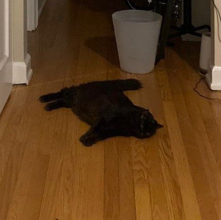

“woe is cat”

Low Dispersion

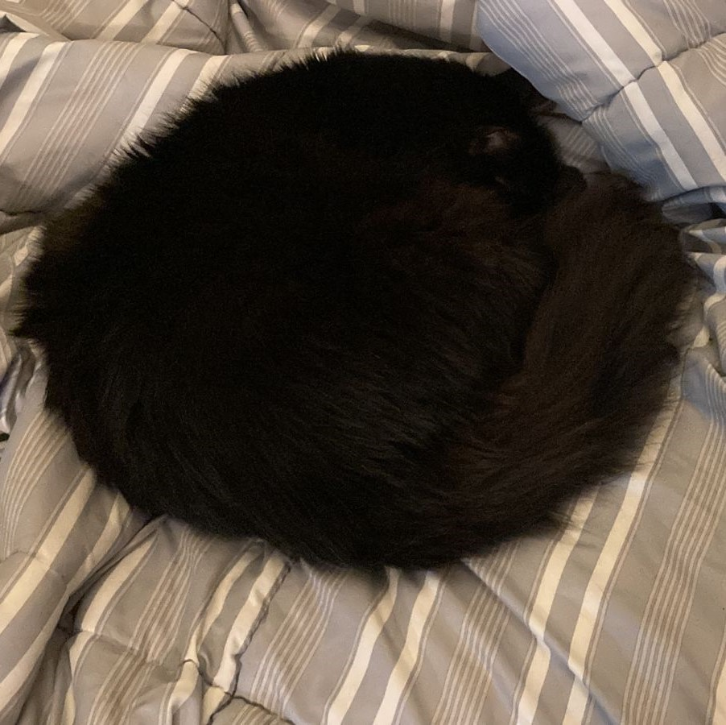

concentrated floof

## Variance

The variance ($s^2$) measures how dispersed data are around the mean. Typically we use the *sample* variance:

$$s^2 = \frac{\sum (x_i - \bar{x})^2}{n - 1}$$

We’ll see this in action next week when we look at distributions.

```r
(s2 <- sum((x - mean(x))^2) / (length(x) -1))
```

```
[1] 52.8
```

```r
var(x)
```

```
[1] 52.8
```

If every value is the same, the variance is *zero*—the data would be *invariant*.

## Standard deviation

The standard deviation ( $s$ or $sd$ ) is just the square root of the variance:

$$s = sd = \sqrt{s^2}$$

You can interpret it as the “typical” distance of values in the data from the mean.

```r
sqrt(var(x))
```

```
[1] 7.266361
```

```r
sd(x)
```

```
[1] 7.266361
```

*Values are about 7.3 away from the mean on average*

# Lines

[figure not shown]

## Cartesian plane

[figure not shown]

## Slope-intercept

Mathematically, lines can be defined by a slope and an intercept.

You’ve seen this before, perhaps many moons ago:

$$y = mx + b$$

We’ll restate it this way:

$$y = a + bx$$

$a$ is the **intercept**

- The value of $y$ when $x = 0$

$b$ is the **slope**

- The units of $y$ the line rises for every unit increase in $x$
- You can restate this as the *ratio* or *coefficient* that $y$ increases relative to $x$

## Intercept

$y = 1 + 0.5x$

```r
plot(c(0,5), c(0,5), type = "n", xlab = "x", ylab = "y", xaxs = "i", yaxs = "i")
abline(a = 1, b = 0.5)
```

[figure not shown]

The line *intercepts* the y-axis at 1.

## Intercept

$y = 3 + 0.5x$

```r
plot(c(0,5), c(0,5), type = "n", xlab = "x", ylab = "y", xaxs = "i", yaxs = "i")
abline(a = 3, b = 0.5)
```

[figure not shown]

The line *intercepts* the y-axis at 3.

## Intercept

$y = 2 + 0.5x$

```r
plot(c(0,5), c(0,5), type = "n", xlab = "x", ylab = "y", xaxs = "i", yaxs = "i")
abline(a = 2, b = 0.5)
```

[figure not shown]

The line *intercepts* the y-axis at 2.

## Slope

$y = 2 + 0.5x$

```r
plot(c(0,5), c(0,5), type = "n", xlab = "x", ylab = "y", xaxs = "i", yaxs = "i")
abline(a = 2, b = 0.5)
```

[figure not shown]

From 2, the line increases by 0.5 for every $x$.

## Slope

$y = 2 + 0x$

```r
plot(c(0,5), c(0,5), type = "n", xlab = "x", ylab = "y", xaxs = "i", yaxs = "i")
abline(a = 2, b = 0)
```

[figure not shown]

From 2, the line increases by 0 for every $x$.

## Slope

$y = 2 + 2x$

```r
plot(c(0,5), c(0,5), type = "n", xlab = "x", ylab = "y", xaxs = "i", yaxs = "i")
abline(a = 2, b = 2)
```

[figure not shown]

From 2, the line increases by 2 for every $x$.

# A little bit of calculus

[figure not shown]